# week_06_categorical_inputs_dummy_vs_onehot

### Linear Models: Categorical inputs compare Dummies to Onehots

## Import Modules

```python
import numpy as np
import pandas as pd
import matplotlib.pyplot as plt

import seaborn as sns
```

```python
import statsmodels.formula.api as smf
```

## Read Data

```python
dfA1 = pd.read_csv('week_06_example_A_1.csv')
```

```python
dfA1.info()
```

```
<class 'pandas.core.frame.DataFrame'>
RangeIndex: 33 entries, 0 to 32
Data columns (total 3 columns):
 #   Column  Non-Null Count  Dtype
---  ------  --------------  -----
 0   x1      33 non-null     float64
 1   x2      33 non-null     object
 2   y       33 non-null     float64
dtypes: float64(2), object(1)
memory usage: 920.0+ bytes
```

```python
dfA1.nunique()
```

```
x1    33
x2     3
y     33
dtype: int64
```

In this example, we will only focus on the relationship between the NON-NUMERIC or Categorical input `x2` and the output `y`. The next video demonstrates how to work with **both** categorical and numeric inputs.

### Quick EDA

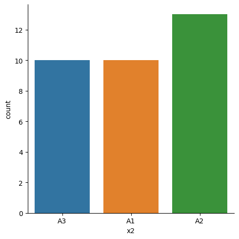

```python
sns.catplot(data = dfA1, x='x2', kind='count')

plt.show()
```

```python
dfA1.x2.value_counts()
```

```
x2
A2    13
A3    10
A1    10
Name: count, dtype: int64
```

```python
dfA1.x2.value_counts(normalize=True)
```

```
x2
A2    0.393939
A3    0.303030
A1    0.303030
Name: proportion, dtype: float64
```

The relationship between the NUMERIC or CONTINUOUS output `y` and the categorical input `x2` should be explored with boxplots, violin plots, conditional kde plots, and point plots.

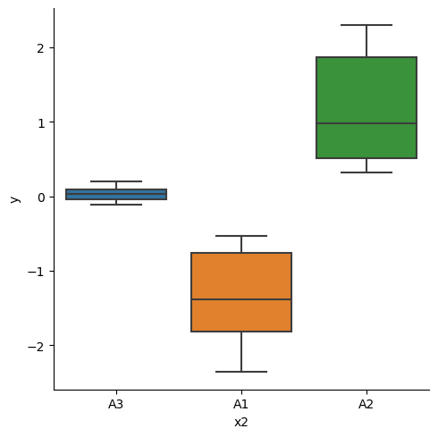

```python
sns.catplot(data = dfA1, x='x2', y='y', kind='box')

plt.show()
```

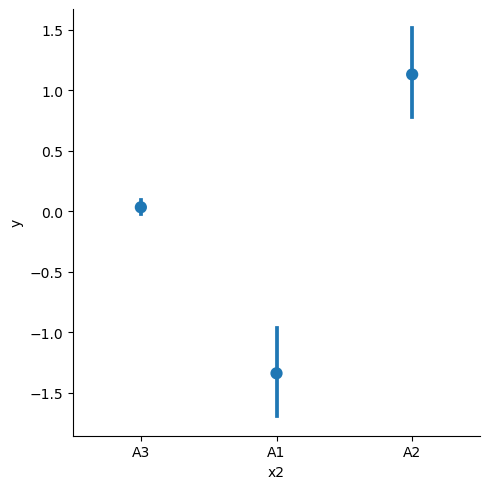

```python
sns.catplot(data = dfA1, x='x2', y='y', kind='point', join=False)

plt.show()
```

## Linear Models

Even though we are focused on categorical inputs in this example, we **should always** fit an INTERCEPT-ONLY or constant average model **first**.

```python
fit_A_0 = smf.ols(formula='y ~ 1', data=dfA1).fit()
```

```python
fit_A_0.params
```

```
Intercept    0.048619
dtype: float64
```

```python
fit_A_0.bse
```

```
Intercept    0.205135
dtype: float64
```

When there are **NO** inputs to the model AKA we have INTERCEPT-ONLY model, the INTERCEPT equals the AVERAGE OUTPUT!

```python
dfA1.y.mean()
```

```
0.04861898948373133
```

```python
dfA1.y.sem()
```

```
0.20513480766054165
```

Next, let's fit the model that ONLY includes the **categorical input**!

This model has **one and only one** input.

Last week, when we fit a linear model with a single input linearly related to the (average) output, there were 2 coefficients estimated. The intercept and the slope multiplying the input.

Let's see what happens we use a model with a single categorical input.

```python
fit_A_1 = smf.ols(formula='y ~ x2', data=dfA1).fit()
```

```python
fit_A_1.params
```

```
Intercept   -1.339974
x2[T.A2]     2.469504
x2[T.A3]     1.372002
dtype: float64
```

```python
fit_A_1.bse
```

```
Intercept    0.182239
x2[T.A2]     0.242401
x2[T.A3]     0.257725
dtype: float64
```

```python
fit_A_1.conf_int().\
rename(columns={0: 'conf_lwr', 1: 'conf_upr'})
```

|  | conf_lwr | conf_upr |
| --- | --- | --- |
| Intercept | -1.712156 | -0.967792 |
| x2[T.A2] | 1.974455 | 2.964552 |
| x2[T.A3] | 0.845657 | 1.898347 |

```python
fit_A_1.pvalues < 0.05
```

```
Intercept    True
x2[T.A2]     True
x2[T.A3]     True
dtype: bool
```

```python
def my_coefplot(mod, figsize_use=(10,4)):
    fig, ax = plt.subplots(figsize=figsize_use)

    ax.errorbar(y =mod.params.index,
                x =mod.params,
                xerr = 2 * mod.bse,
                fmt='o', color='k', ecolor='k', elinewidth=2, ms=10)

    ax.axvline(x=0, linestyle='--', color='grey', linewidth=3.5)

    ax.set_xlabel('coefficient value')

    plt.show()
```

```python
my_coefplot( fit_A_1 )
```

[output not shown]

But why are there 3 coefficients even though there is 1 and only 1 input????

The reason is because the input is CATEGORICAL and has 3 categories!!!

Let's begin understanding how the categorical input "works" by examining **predictions**.

Let's use the TRAINING SET predictions first. The TRAINING SET predictions are called the FITS or FITTEDVALUES.

```python
dfA1_copy = dfA1.copy()
```

```python
dfA1_copy['fits_1'] = fit_A_1.fittedvalues
```

```python
dfA1_copy.head()
```

|  | x1 | x2 | y | fits_1 |
| --- | --- | --- | --- | --- |
| 0 | 1.340015 | A3 | -0.107934 | 0.032028 |
| 1 | -1.575463 | A1 | -1.833471 | -1.339974 |
| 2 | 1.595778 | A2 | 1.925451 | 1.129530 |
| 3 | -0.758101 | A2 | 0.826788 | 1.129530 |
| 4 | 1.299439 | A3 | -0.083876 | 0.032028 |

```python
dfA1_copy.nunique()
```

```
x1        33
x2         3
y         33
fits_1     3
dtype: int64
```

```python
dfA1_copy.x2.value_counts()
```

```
x2
A2    13
A3    10
A1    10
Name: count, dtype: int64
```

```python
dfA1_copy.fits_1.value_counts()
```

```
fits_1
 1.129530    13
 0.032028    10
-1.339974    10
Name: count, dtype: int64
```

The above values PREDICTED by the model correspond to the AVERAGE OUTPUT for each category!

```python
dfA1_copy.groupby(['x2']).y.mean()
```

```
x2
A1   -1.339974
A2    1.129530
A3    0.032028
Name: y, dtype: float64
```

Let's now use `.groupby().aggregate()` to compare the AVERAGE PER GROUP side-by-side with the model predictions.

```python
dfA1_copy.groupby(['x2']).\
aggregate(num_rows = ('y', 'count'),
          avg_y = ('y', 'mean'),
          num_unique_y = ('y', 'nunique'),
          pred = ('fits_1', 'mean'),
          num_unique_pred = ('fits_1', 'nunique')).\
reset_index()
```

|  | x2 | num_rows | avg_y | num_unique_y | pred | num_unique_pred |
| --- | --- | --- | --- | --- | --- | --- |
| 0 | A1 | 10 | -1.339974 | 10 | -1.339974 | 1 |
| 1 | A2 | 13 | 1.129530 | 13 | 1.129530 | 1 |
| 2 | A3 | 10 | 0.032028 | 10 | 0.032028 | 1 |

But, how does this actually happen? How can the model prediction **change** across the groups?

Let's now examine the DESIGN MATRIX of the INPUT FEATURE ARRAY.

```python
from patsy import dmatrices
```

```python
yA1_df_1, XA1_df_1 = dmatrices('y ~ x2', data=dfA1, return_type='dataframe')
```

```python
yA1_df_1.head()
```

|  | y |
| --- | --- |
| 0 | -0.107934 |
| 1 | -1.833471 |
| 2 | 1.925451 |
| 3 | 0.826788 |
| 4 | -0.083876 |

```python
XA1_df_1.head()
```

|  | Intercept | x2[T.A2] | x2[T.A3] |
| --- | --- | --- | --- |
| 0 | 1.0 | 0.0 | 1.0 |
| 1 | 1.0 | 0.0 | 0.0 |
| 2 | 1.0 | 1.0 | 0.0 |
| 3 | 1.0 | 1.0 | 0.0 |
| 4 | 1.0 | 0.0 | 1.0 |

```python
XA1_df_1.tail()
```

|  | Intercept | x2[T.A2] | x2[T.A3] |
| --- | --- | --- | --- |
| 28 | 1.0 | 1.0 | 0.0 |
| 29 | 1.0 | 0.0 | 1.0 |
| 30 | 1.0 | 1.0 | 0.0 |
| 31 | 1.0 | 0.0 | 1.0 |
| 32 | 1.0 | 1.0 | 0.0 |

```python
fit_A_1.params
```

```
Intercept   -1.339974
x2[T.A2]     2.469504
x2[T.A3]     1.372002
dtype: float64
```

```python
XA1_df_1.nunique()
```

```
Intercept    1
x2[T.A2]     2
x2[T.A3]     2
dtype: int64
```

```python
XA1_df_1.Intercept.value_counts()
```

```
Intercept
1.0    33
Name: count, dtype: int64
```

```python
XA1_df_1['x2[T.A2]'].value_counts()
```

```
x2[T.A2]
0.0    20
1.0    13
Name: count, dtype: int64
```

```python
XA1_df_1['x2[T.A3]'].value_counts()
```

```
x2[T.A3]
0.0    23
1.0    10
Name: count, dtype: int64
```

```python
dfA1.x2.value_counts()
```

```
x2
A2    13
A3    10
A1    10
Name: count, dtype: int64
```

Dummies are BINARY indicators. A value of 0 means that Dummy's category **is NOT present** while a value of 1 means that Dummy's category **is present** for a row in the data.

```python
dfA1.head()
```

|  | x1 | x2 | y |
| --- | --- | --- | --- |
| 0 | 1.340015 | A3 | -0.107934 |
| 1 | -1.575463 | A1 | -1.833471 |
| 2 | 1.595778 | A2 | 1.925451 |
| 3 | -0.758101 | A2 | 0.826788 |
| 4 | 1.299439 | A3 | -0.083876 |

```python
XA1_df_1.head()
```

|  | Intercept | x2[T.A2] | x2[T.A3] |
| --- | --- | --- | --- |
| 0 | 1.0 | 0.0 | 1.0 |
| 1 | 1.0 | 0.0 | 0.0 |
| 2 | 1.0 | 1.0 | 0.0 |
| 3 | 1.0 | 1.0 | 0.0 |
| 4 | 1.0 | 0.0 | 1.0 |

If all DUMMIES equal 0 for a ROW, then the input equals the **REFERENCE category**!!!!

Dummy variables require a REFERENCE POINT to be identified. By default, that reference point is the first category alphabetically.

This means, the number of features derived from a categorical input EQUALS the number of categories **minus 1**.

```python
dfA1.head(10)
```

|  | x1 | x2 | y |
| --- | --- | --- | --- |
| 0 | 1.340015 | A3 | -0.107934 |
| 1 | -1.575463 | A1 | -1.833471 |
| 2 | 1.595778 | A2 | 1.925451 |
| 3 | -0.758101 | A2 | 0.826788 |
| 4 | 1.299439 | A3 | -0.083876 |
| 5 | -0.155842 | A1 | -0.596064 |
| 6 | 1.687946 | A1 | -2.361652 |
| 7 | -1.424593 | A1 | -1.786179 |
| 8 | 0.901814 | A2 | 0.983535 |
| 9 | -0.178357 | A2 | 0.475464 |

```python
XA1_df_1.head(10)
```

|  | Intercept | x2[T.A2] | x2[T.A3] |
| --- | --- | --- | --- |
| 0 | 1.0 | 0.0 | 1.0 |
| 1 | 1.0 | 0.0 | 0.0 |
| 2 | 1.0 | 1.0 | 0.0 |
| 3 | 1.0 | 1.0 | 0.0 |
| 4 | 1.0 | 0.0 | 1.0 |
| 5 | 1.0 | 0.0 | 0.0 |
| 6 | 1.0 | 0.0 | 0.0 |
| 7 | 1.0 | 0.0 | 0.0 |
| 8 | 1.0 | 1.0 | 0.0 |
| 9 | 1.0 | 1.0 | 0.0 |

Even though the input is NON-NUMERIC **behind the scenes** numeric (integer) features are **derived**. The derived **dummy variables** are either 0 or 1.

This means making predictions **works the same way** as with numeric inputs!

The coefficients multiply the features and their products are summed!!!!!!!

Let's see how the coefficients and features are used to make the predictions.

```python
fit_A_1.params
```

```
Intercept   -1.339974
x2[T.A2]     2.469504
x2[T.A3]     1.372002
dtype: float64
```

```python
XA1_df_1['intercept_product'] = XA1_df_1.Intercept * -1.339974
```

```python
XA1_df_1['dummy2_product'] = XA1_df_1['x2[T.A2]'] * 2.469504
```

```python
XA1_df_1['dummy3_product'] = XA1_df_1['x2[T.A3]'] * 1.372002
```

```python
XA1_df_1.head()
```

|  | Intercept | x2[T.A2] | x2[T.A3] | intercept_product | dummy2_product | dummy3_product |
| --- | --- | --- | --- | --- | --- | --- |
| 0 | 1.0 | 0.0 | 1.0 | -1.339974 | 0.000000 | 1.372002 |
| 1 | 1.0 | 0.0 | 0.0 | -1.339974 | 0.000000 | 0.000000 |
| 2 | 1.0 | 1.0 | 0.0 | -1.339974 | 2.469504 | 0.000000 |
| 3 | 1.0 | 1.0 | 0.0 | -1.339974 | 2.469504 | 0.000000 |
| 4 | 1.0 | 0.0 | 1.0 | -1.339974 | 0.000000 | 1.372002 |

```python
XA1_df_1['model_pred'] = XA1_df_1.intercept_product + XA1_df_1.dummy2_product + XA1_df_1.dummy3_product
```

```python
XA1_df_1.head()
```

|  | Intercept | x2[T.A2] | x2[T.A3] | intercept_product | dummy2_product | dummy3_product | model_pred |
| --- | --- | --- | --- | --- | --- | --- | --- |
| 0 | 1.0 | 0.0 | 1.0 | -1.339974 | 0.000000 | 1.372002 | 0.032028 |
| 1 | 1.0 | 0.0 | 0.0 | -1.339974 | 0.000000 | 0.000000 | -1.339974 |
| 2 | 1.0 | 1.0 | 0.0 | -1.339974 | 2.469504 | 0.000000 | 1.129530 |
| 3 | 1.0 | 1.0 | 0.0 | -1.339974 | 2.469504 | 0.000000 | 1.129530 |
| 4 | 1.0 | 0.0 | 1.0 | -1.339974 | 0.000000 | 1.372002 | 0.032028 |

```python
fit_A_1.params
```

```
Intercept   -1.339974
x2[T.A2]     2.469504
x2[T.A3]     1.372002
dtype: float64
```

```python
dfA1_copy.groupby(['x2']).y.mean()
```

```
x2
A1   -1.339974
A2    1.129530
A3    0.032028
Name: y, dtype: float64
```

Categorical inputs therefore cause the INTERCEPT to have a real meaning. The INTERCEPT equals the AVERAGE OUTPUT **at** the reference category!!!!

The dummy variable coefficients also have an important physical meaning. We **add** the dummy coefficients to the intercept. The dummy coefficients are therefore the **RELATIVE effect** from the **REFERENCE**!!!!!

Statistical significance for dummy coefficients therefore means are we confident the category has an effect **relative** to the reference!!

```python
my_coefplot( fit_A_1 )
```

[output not shown]

## Explore numeric input

```python
dfA1.info()
```

```
<class 'pandas.core.frame.DataFrame'>
RangeIndex: 33 entries, 0 to 32
Data columns (total 3 columns):
 #   Column  Non-Null Count  Dtype
---  ------  --------------  -----
 0   x1      33 non-null     float64
 1   x2      33 non-null     object
 2   y       33 non-null     float64
dtypes: float64(2), object(1)
memory usage: 920.0+ bytes
```

Visualize the relationship between the continuous or numeric output `y` with the numeric input `x1`.

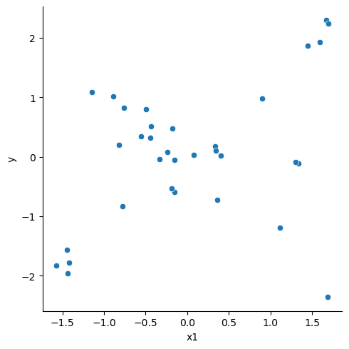

```python
sns.relplot(data = dfA1, x='x1', y='y')

plt.show()
```

Include a linear TREND LINE it can help reveal a basic linear relationship within the data.

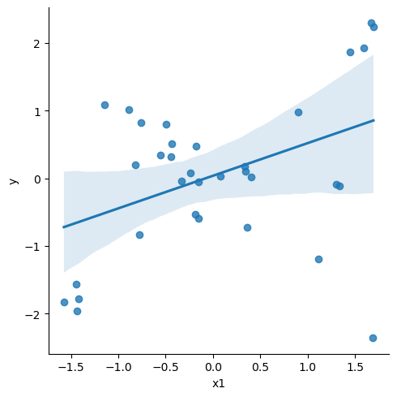

```python
sns.lmplot(data = dfA1, x='x1', y='y')

plt.show()
```

But, we cannot forget that there is a categorical input also included in this example!

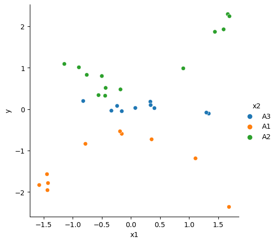

```python
sns.relplot(data = dfA1, x='x1', y='y', hue='x2')

plt.show()
```

We can also color the TREND LINE by a categorical to help see IF the output to continuous input relationship changes across the categories!

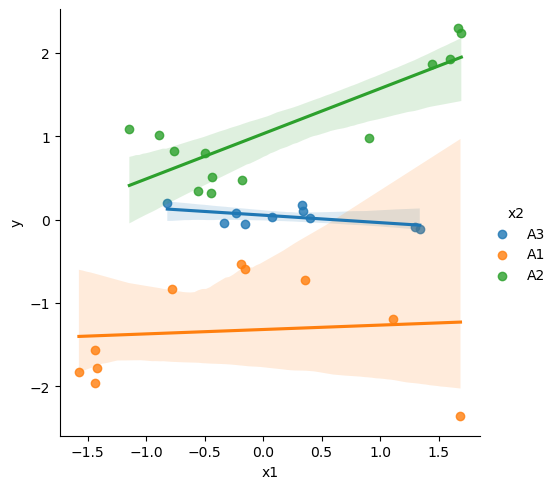

```python
sns.lmplot(data = dfA1, x='x1', y='y', hue='x2')

plt.show()
```

Non-linear output to continuous input relationships can also change across categories!

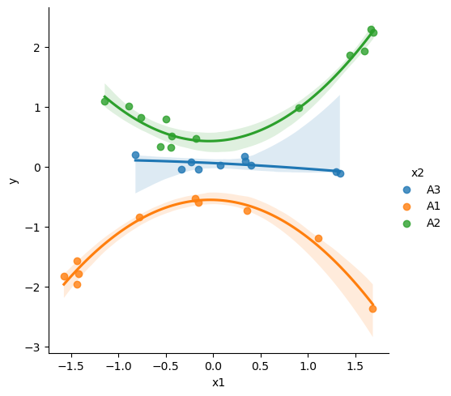

```python
sns.lmplot(data = dfA1, x='x1', y='y', hue='x2', order=2)

plt.show()
```

## Working with linear models with Mixed Inputs

General workflow:

- Fit an INTERCEPT-ONLY linear model
- Fit a model with ONLY the categorical inputs
- Fit a model with ONLY the linear additive continuous inputs
- Fit models with MIXED INPUTS - categorical and continuous inputs

The previous recording already fit the INTERCEPT-ONLY and the categorical only models. So let's fit the continuous only model.

```python
fit_A_1c = smf.ols(formula='y ~ x1', data=dfA1).fit()
```

```python
fit_A_1c.params
```

```
Intercept    0.036752
x1           0.481947
dtype: float64
```

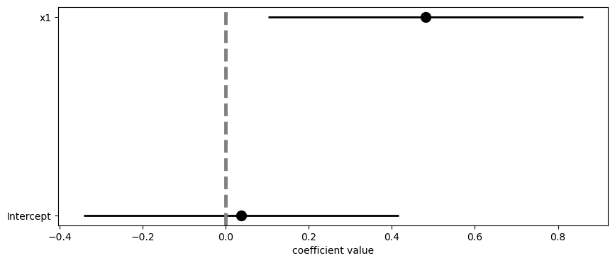

```python
my_coefplot( fit_A_1c )
```

```python
fit_A_1c.pvalues < 0.05
```

```
Intercept    False
x1            True
dtype: bool
```

### Mixed Input models

We have the same set of choices with mixed inputs as we do with multiple numeric inputs. Meaning, we must decide if we want **ADDITIVE** vs **INTERACTION** features!!!!

### Linear additive features

```python
fit_A_2 = smf.ols(formula='y ~ x1 + x2', data=dfA1).fit()
```

```python
fit_A_2.params
```

```
Intercept   -1.239350
x2[T.A2]     2.320476
x2[T.A3]     1.212401
x1           0.261887
dtype: float64
```

It can be useful to FIRST check the DESIGN MATRIX of INPUT FEATURE ARRAY **before** fitting the model!!!!

```python
yA1_df_2, XA1_df_2 = dmatrices('y ~ x1 + x2', data=dfA1, return_type='dataframe')
```

```python
XA1_df_2.shape
```

```
(33, 4)
```

```python
XA1_df_1.head()
```

|  | Intercept | x2[T.A2] | x2[T.A3] | intercept_product | dummy2_product | dummy3_product | model_pred |
| --- | --- | --- | --- | --- | --- | --- | --- |
| 0 | 1.0 | 0.0 | 1.0 | -1.339974 | 0.000000 | 1.372002 | 0.032028 |
| 1 | 1.0 | 0.0 | 0.0 | -1.339974 | 0.000000 | 0.000000 | -1.339974 |
| 2 | 1.0 | 1.0 | 0.0 | -1.339974 | 2.469504 | 0.000000 | 1.129530 |
| 3 | 1.0 | 1.0 | 0.0 | -1.339974 | 2.469504 | 0.000000 | 1.129530 |
| 4 | 1.0 | 0.0 | 1.0 | -1.339974 | 0.000000 | 1.372002 | 0.032028 |

```python
XA1_df_2.head()
```

|  | Intercept | x2[T.A2] | x2[T.A3] | x1 |
| --- | --- | --- | --- | --- |
| 0 | 1.0 | 0.0 | 1.0 | 1.340015 |
| 1 | 1.0 | 0.0 | 0.0 | -1.575463 |
| 2 | 1.0 | 1.0 | 0.0 | 1.595778 |
| 3 | 1.0 | 1.0 | 0.0 | -0.758101 |
| 4 | 1.0 | 0.0 | 1.0 | 1.299439 |

```python
fit_A_2.pvalues < 0.05
```

```
Intercept    True
x2[T.A2]     True
x2[T.A3]     True
x1           True
dtype: bool
```

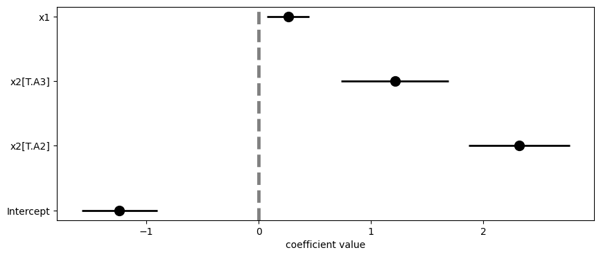

```python
my_coefplot( fit_A_2 )
```

When there is a single categorical input and ZERO continuous (numeric) inputs, the INTERCEPT is the **average output** for the REFERENCE category.

```python
fit_A_1.params
```

```
Intercept   -1.339974
x2[T.A2]     2.469504
x2[T.A3]     1.372002
dtype: float64
```

```python
dfA1.groupby(['x2']).y.mean()
```

```
x2
A1   -1.339974
A2    1.129530
A3    0.032028
Name: y, dtype: float64
```

```python
fit_A_2.params
```

```
Intercept   -1.239350
x2[T.A2]     2.320476
x2[T.A3]     1.212401
x1           0.261887
dtype: float64
```

The INTERCEPT in general is the AVERAGE OUTPUT **given** ALL FEATURES equaling ZERO!!!!

When we have mixed inputs, that corresponds to the categorical input equaling the REFERENCE category and the continuous inputs equaling zero.

Predictions will help visualize the TRENDS so we can examine what happens ACROSS the categories!!!

We will **NOT** look at the TRAINING SET fits! Instead, we will make predictions on NEW data!

The new data **MUST** include **all** inputs used in the model!!!!!

Since we have just 2 inputs, let's consider MANY unique values between the TRAINING SET min/max for the continuous input and **ALL** categories for the categorical input.

```python
np.linspace(dfA1.x1.min(), dfA1.x1.max(), num=5)
```

```
array([-1.57546346, -0.75777303,  0.0599174 ,  0.87760783,  1.69529826])
```

```python
dfA1.x2.unique()
```

```
array(['A3', 'A1', 'A2'], dtype=object)
```

```python
dfA1.x2.unique().tolist()
```

```
['A3', 'A1', 'A2']
```

We can use LIST COMPREHENSIONS to create a GRID of all combinations of the 2 inputs!

```python
input_grid = pd.DataFrame( [ (x1, x2) for x1 in np.linspace(dfA1.x1.min(), dfA1.x1.max(), num=101)
                                      for x2 in dfA1.x2.unique().tolist() ],
                           columns=['x1', 'x2'])
```

```python
input_grid
```

|  | x1 | x2 |
| --- | --- | --- |
| 0 | -1.575463 | A3 |
| 1 | -1.575463 | A1 |
| 2 | -1.575463 | A2 |
| 3 | -1.542756 | A3 |
| 4 | -1.542756 | A1 |
| ... | ... | ... |
| 298 | 1.662591 | A1 |
| 299 | 1.662591 | A2 |
| 300 | 1.695298 | A3 |
| 301 | 1.695298 | A1 |
| 302 | 1.695298 | A2 |

303 rows × 2 columns

```python
input_grid.nunique()
```

```
x1    101
x2      3
dtype: int64
```

Make a copy of the `input_grid` and then ADD new columns for the PREDICTIONS for the models!

```python
viz_grid = input_grid.copy()
```

```python
viz_grid['pred_2'] = fit_A_2.predict( input_grid )
```

```python
viz_grid
```

|  | x1 | x2 | pred_2 |
| --- | --- | --- | --- |
| 0 | -1.575463 | A3 | -0.439543 |
| 1 | -1.575463 | A1 | -1.651943 |
| 2 | -1.575463 | A2 | 0.668533 |
| 3 | -1.542756 | A3 | -0.430977 |
| 4 | -1.542756 | A1 | -1.643378 |
| ... | ... | ... | ... |
| 298 | 1.662591 | A1 | -0.803940 |
| 299 | 1.662591 | A2 | 1.516536 |
| 300 | 1.695298 | A3 | 0.417027 |
| 301 | 1.695298 | A1 | -0.795374 |
| 302 | 1.695298 | A2 | 1.525102 |

303 rows × 3 columns

Visualize the predictions as a LINE CHART!!!!

```python
viz_grid.nunique()
```

```
x1        101
x2          3
pred_2    303
dtype: int64
```

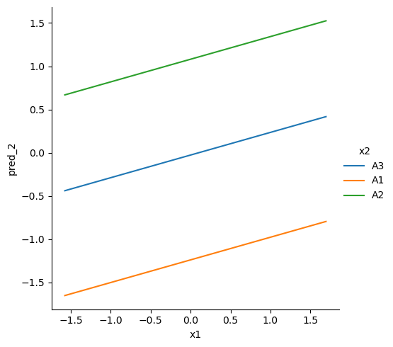

```python
sns.relplot( data=viz_grid, x='x1', y='pred_2', hue='x2',
             kind='line',
             estimator=None, units='x2' )

plt.show()
```

```python
fit_A_2.params
```

```
Intercept   -1.239350
x2[T.A2]     2.320476
x2[T.A3]     1.212401
x1           0.261887
dtype: float64
```

```python
XA1_df_2.head()
```

|  | Intercept | x2[T.A2] | x2[T.A3] | x1 |
| --- | --- | --- | --- | --- |
| 0 | 1.0 | 0.0 | 1.0 | 1.340015 |
| 1 | 1.0 | 0.0 | 0.0 | -1.575463 |
| 2 | 1.0 | 1.0 | 0.0 | 1.595778 |
| 3 | 1.0 | 1.0 | 0.0 | -0.758101 |
| 4 | 1.0 | 0.0 | 1.0 | 1.299439 |

```python
fit_A_2.params
```

```
Intercept   -1.239350
x2[T.A2]     2.320476
x2[T.A3]     1.212401
x1           0.261887
dtype: float64
```

### Interactions between the categorical and linear features

We can **MULTIPLY** or **INTERACT** the inputs together!

```python
fit_A_3 = smf.ols(formula='y ~ x1 * x2', data=dfA1).fit()
```

```python
fit_A_3.params
```

```
Intercept     -1.319719
x2[T.A2]       2.349054
x2[T.A3]       1.371903
x1             0.052717
x1:x2[T.A2]    0.489376
x1:x2[T.A3]   -0.142218
dtype: float64
```

```python
fit_A_3.pvalues < 0.05
```

```
Intercept       True
x2[T.A2]        True
x2[T.A3]        True
x1             False
x1:x2[T.A2]     True
x1:x2[T.A3]    False
dtype: bool
```

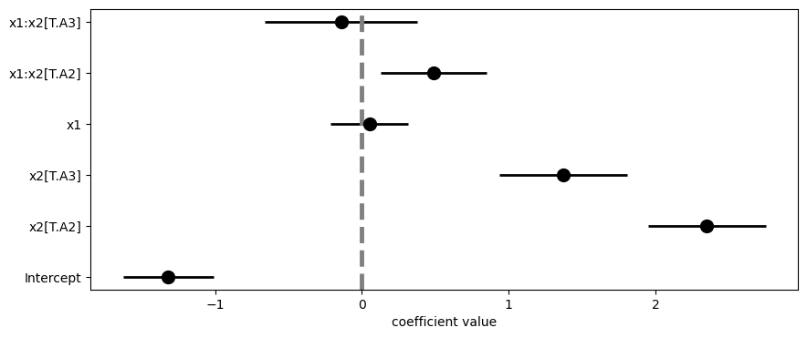

```python
my_coefplot( fit_A_3 )
```

First, check the DESIGN MATRIX or FEATURE ARRAY before fitting the model!!!!!!

```python
yA1_df_3, XA1_df_3 = dmatrices('y ~ x1 * x2', data=dfA1, return_type='dataframe')
```

```python
XA1_df_3.head()
```

|  | Intercept | x2[T.A2] | x2[T.A3] | x1 | x1:x2[T.A2] | x1:x2[T.A3] |
| --- | --- | --- | --- | --- | --- | --- |
| 0 | 1.0 | 0.0 | 1.0 | 1.340015 | 0.000000 | 1.340015 |
| 1 | 1.0 | 0.0 | 0.0 | -1.575463 | -0.000000 | -0.000000 |
| 2 | 1.0 | 1.0 | 0.0 | 1.595778 | 1.595778 | 0.000000 |
| 3 | 1.0 | 1.0 | 0.0 | -0.758101 | -0.758101 | -0.000000 |
| 4 | 1.0 | 0.0 | 1.0 | 1.299439 | 0.000000 | 1.299439 |

```python
fit_A_3.params
```

```
Intercept     -1.319719
x2[T.A2]       2.349054
x2[T.A3]       1.371903
x1             0.052717
x1:x2[T.A2]    0.489376
x1:x2[T.A3]   -0.142218
dtype: float64
```

```python
1.0 * -1.319719 + 0.0*2.349054 + 1.0*1.371903 + 1.340015 * (0.052717 + 0*0.489376 + 1*-0.142218)
```

```
-0.067748682515
```

```python
fit_A_3.fittedvalues[:5]
```

```
0   -0.067749
1   -1.402773
2    1.894395
3    0.618374
4   -0.064118
dtype: float64
```

Repeat these actions for row 1.

```python
1.0 * -1.319719 + 0.0*2.349054 + 0.0*1.371903 + -1.575463 * (0.052717 + 0*0.489376 + 0*-0.142218)
```

```
-1.402772682971
```

We are defining a NEW effective SLOPE that multiplies the CONTINUOUS input!!!

When `x2=='A3'` the slope multiplying `x1` is **NOT** 0.052717!!

```python
(0.052717 + 0*0.489376 + 1*-0.142218)
```

```
-0.08950100000000001
```

When `x2=='A2'` the SLOPE multyping `x1` is **NOT** 0.52717!!

```python
(0.052717 + 1*0.489376 + 0*-0.142218)
```

```
0.5420929999999999
```

When `x2=='A1'` the SLOPE multiplying `x1` IS equal to the MAIN EFFECT!!

```python
(0.052717 + 0*0.489376 + 0*-0.142218)
```

```
0.052717
```

When you INTERACT a categorical with a continuous input...the MAIN EFFECT slope is **REALLY** the slope or RELATIONSHIP between the output and continuous input at the the REFERENCE category!!!!

Confirm by visualizing predictions!!

```python
viz_grid['pred_3'] = fit_A_3.predict( input_grid )
```

```python
viz_grid
```

|  | x1 | x2 | pred_2 | pred_3 |
| --- | --- | --- | --- | --- |
| 0 | -1.575463 | A3 | -0.439543 | 0.193190 |
| 1 | -1.575463 | A1 | -1.651943 | -1.402773 |
| 2 | -1.575463 | A2 | 0.668533 | 0.175288 |
| 3 | -1.542756 | A3 | -0.430977 | 0.190263 |
| 4 | -1.542756 | A1 | -1.643378 | -1.401048 |
| ... | ... | ... | ... | ... |
| 298 | 1.662591 | A1 | -0.803940 | -1.232072 |
| 299 | 1.662591 | A2 | 1.516536 | 1.930614 |
| 300 | 1.695298 | A3 | 0.417027 | -0.099548 |
| 301 | 1.695298 | A1 | -0.795374 | -1.230348 |
| 302 | 1.695298 | A2 | 1.525102 | 1.948344 |

303 rows × 4 columns

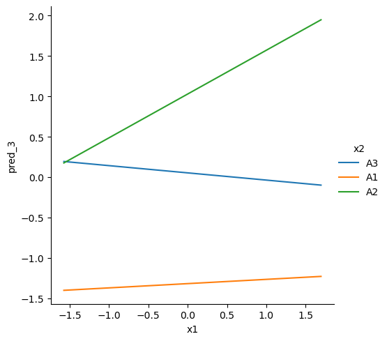

```python
sns.relplot(data = viz_grid, x='x1', y='pred_3', hue='x2',
            kind='line',
            estimator=None, units='x2')

plt.show()
```

### Add categorical inputs to non-linear features derived from continuous inputs

```python
fit_A_4 = smf.ols(formula='y ~ x1 + np.power(x1, 2) + x2', data=dfA1).fit()
```

```python
fit_A_4.params
```

```
Intercept         -1.181059
x2[T.A2]           2.302956
x2[T.A3]           1.168783
x1                 0.277933
np.power(x1, 2)   -0.038530
dtype: float64
```

```python
fit_A_4.pvalues < 0.05
```

```
Intercept           True
x2[T.A2]            True
x2[T.A3]            True
x1                  True
np.power(x1, 2)    False
dtype: bool
```

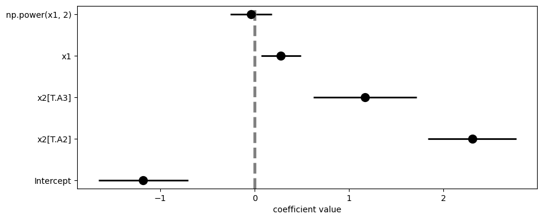

```python
my_coefplot( fit_A_4 )
```

```python
viz_grid['pred_4'] = fit_A_4.predict( input_grid )
```

```python
viz_grid
```

|  | x1 | x2 | pred_2 | pred_3 | pred_4 |
| --- | --- | --- | --- | --- | --- |
| 0 | -1.575463 | A3 | -0.439543 | 0.193190 | -0.545784 |
| 1 | -1.575463 | A1 | -1.651943 | -1.402773 | -1.714568 |
| 2 | -1.575463 | A2 | 0.668533 | 0.175288 | 0.588389 |
| 3 | -1.542756 | A3 | -0.430977 | 0.190263 | -0.532764 |
| 4 | -1.542756 | A1 | -1.643378 | -1.401048 | -1.701547 |
| ... | ... | ... | ... | ... | ... |
| 298 | 1.662591 | A1 | -0.803940 | -1.232072 | -0.825474 |
| 299 | 1.662591 | A2 | 1.516536 | 1.930614 | 1.477482 |
| 300 | 1.695298 | A3 | 0.417027 | -0.099548 | 0.348168 |
| 301 | 1.695298 | A1 | -0.795374 | -1.230348 | -0.820615 |
| 302 | 1.695298 | A2 | 1.525102 | 1.948344 | 1.482341 |

303 rows × 5 columns

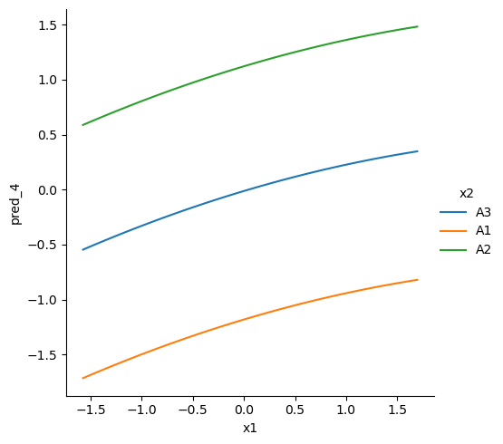

```python
sns.relplot(data = viz_grid, x='x1', y='pred_4', hue='x2',
            kind='line',
            estimator=None, units='x2')

plt.show()
```

### Interact the categorical input with non-linear features derived from the numeric input

```python
yA1_df_5, XA1_df_5 = dmatrices('y ~ x2 * ( x1 + np.power(x1, 2) )', data=dfA1, return_type='dataframe')
```

```python
XA1_df_5.shape
```

```
(33, 9)
```

```python
XA1_df_5.head()
```

|  | Intercept | x2[T.A2] | x2[T.A3] | x1 | x2[T.A2]:x1 | x2[T.A3]:x1 | np.power(x1, 2) | x2[T.A2]:np.power(x1, 2) | x2[T.A3]:np.power(x1, 2) |
| --- | --- | --- | --- | --- | --- | --- | --- | --- | --- |
| 0 | 1.0 | 0.0 | 1.0 | 1.340015 | 0.000000 | 1.340015 | 1.795639 | 0.000000 | 1.795639 |
| 1 | 1.0 | 0.0 | 0.0 | -1.575463 | -0.000000 | -0.000000 | 2.482085 | 0.000000 | 0.000000 |
| 2 | 1.0 | 1.0 | 0.0 | 1.595778 | 1.595778 | 0.000000 | 2.546507 | 2.546507 | 0.000000 |
| 3 | 1.0 | 1.0 | 0.0 | -0.758101 | -0.758101 | -0.000000 | 0.574718 | 0.574718 | 0.000000 |
| 4 | 1.0 | 0.0 | 1.0 | 1.299439 | 0.000000 | 1.299439 | 1.688543 | 0.000000 | 1.688543 |

```python
fit_A_5 = smf.ols(formula='y ~ x2 * (x1 + np.power(x1, 2))', data=dfA1).fit()
```

```python
fit_A_5.params
```

```
Intercept                  -0.554479
x2[T.A2]                    0.981418
x2[T.A3]                    0.613512
x1                         -0.035975
x2[T.A2]:x1                 0.088304
x2[T.A3]:x1                -0.037594
np.power(x1, 2)            -0.590833
x2[T.A2]:np.power(x1, 2)    1.201249
x2[T.A3]:np.power(x1, 2)    0.568843
dtype: float64
```

```python
fit_A_5.pvalues < 0.05
```

```
Intercept                    True
x2[T.A2]                     True
x2[T.A3]                     True
x1                          False
x2[T.A2]:x1                 False
x2[T.A3]:x1                 False
np.power(x1, 2)              True
x2[T.A2]:np.power(x1, 2)     True
x2[T.A3]:np.power(x1, 2)     True
dtype: bool
```

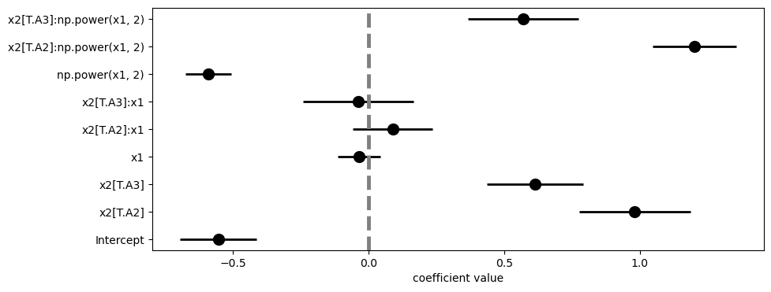

```python
my_coefplot( fit_A_5 )
```

```python
viz_grid['pred_5'] = fit_A_5.predict( input_grid )
```

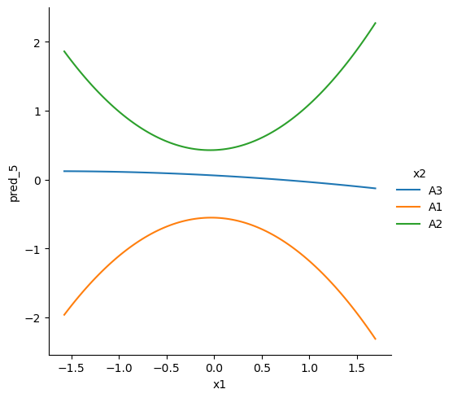

```python
sns.relplot(data = viz_grid, x='x1', y='pred_5', hue='x2',
            kind='line',
            estimator=None, units='x2')

plt.show()
```

## Visualize prediction uncertainty

The predictive trends are important but they are NOT the full story! We also need to communicate the uncertainty on the average (CONFIDENCE INTERVAL) and the uncertainty on a single observation or measurement (PREDICTION INTERVAL).

Last week, we saw how to do that with the `.get_prediction().summary_frame()` methods. However, we only had a single continuous input and so we need to see how to handle the situation when we allow MULTIPLE inputs to vary!!!!!

Everything you are about to see works when there are 2 inputs with varying values in the prediction grid!

```python
input_grid
```

|  | x1 | x2 |
| --- | --- | --- |
| 0 | -1.575463 | A3 |
| 1 | -1.575463 | A1 |
| 2 | -1.575463 | A2 |
| 3 | -1.542756 | A3 |
| 4 | -1.542756 | A1 |
| ... | ... | ... |
| 298 | 1.662591 | A1 |
| 299 | 1.662591 | A2 |
| 300 | 1.695298 | A3 |
| 301 | 1.695298 | A1 |
| 302 | 1.695298 | A2 |

303 rows × 2 columns

```python
input_grid.nunique()
```

```
x1    101
x2      3
dtype: int64
```

Make the predictions and include the UNCERTAINTY INTERVAL bounds using `.get_prediction().summary_frame()` method.

```python
pred_viz_summary_5 = fit_A_5.get_prediction( input_grid ).summary_frame()
```

```python
pred_viz_summary_5.shape
```

```
(303, 6)
```

```python
pred_viz_summary_5.head()
```

|  | mean | mean_se | mean_ci_lower | mean_ci_upper | obs_ci_lower | obs_ci_upper |
| --- | --- | --- | --- | --- | --- | --- |
| 0 | 0.120359 | 0.332210 | -0.565288 | 0.806006 | -0.619837 | 0.860555 |
| 1 | -1.964300 | 0.074686 | -2.118443 | -1.810156 | -2.282950 | -1.645649 |
| 2 | 1.859601 | 0.191346 | 1.464681 | 2.254520 | 1.376135 | 2.343066 |
| 3 | 0.120195 | 0.320654 | -0.541602 | 0.781993 | -0.597965 | 0.838355 |
| 4 | -1.905217 | 0.071770 | -2.053343 | -1.757092 | -2.221000 | -1.589435 |

The input values associated with the predictions are NOT included in the result of `.get_prediction().summary_frame()`.

```python
input_grid.head()
```

|  | x1 | x2 |
| --- | --- | --- |
| 0 | -1.575463 | A3 |
| 1 | -1.575463 | A1 |
| 2 | -1.575463 | A2 |
| 3 | -1.542756 | A3 |
| 4 | -1.542756 | A1 |

Concatenate or **bind** the columns together between `input_grid` and `pred_viz_summary_5` we will have a new dataframe that has all INPUTS and the prediction summaries in one place!

```python
pd.concat( [input_grid, pred_viz_summary_5], axis=1 )
```

|  | x1 | x2 | mean | mean_se | mean_ci_lower | mean_ci_upper | obs_ci_lower | obs_ci_upper |
| --- | --- | --- | --- | --- | --- | --- | --- | --- |
| 0 | -1.575463 | A3 | 0.120359 | 0.332210 | -0.565288 | 0.806006 | -0.619837 | 0.860555 |
| 1 | -1.575463 | A1 | -1.964300 | 0.074686 | -2.118443 | -1.810156 | -2.282950 | -1.645649 |
| 2 | -1.575463 | A2 | 1.859601 | 0.191346 | 1.464681 | 2.254520 | 1.376135 | 2.343066 |
| 3 | -1.542756 | A3 | 0.120195 | 0.320654 | -0.541602 | 0.781993 | -0.597965 | 0.838355 |
| 4 | -1.542756 | A1 | -1.905217 | 0.071770 | -2.053343 | -1.757092 | -2.221000 | -1.589435 |
| ... | ... | ... | ... | ... | ... | ... | ... | ... |
| 298 | 1.662591 | A1 | -2.247477 | 0.115810 | -2.486497 | -2.008457 | -2.614776 | -1.880178 |
| 299 | 1.662591 | A2 | 2.201256 | 0.070692 | 2.055355 | 2.347158 | 1.886511 | 2.516002 |
| 300 | 1.695298 | A3 | -0.128890 | 0.162740 | -0.464769 | 0.206990 | -0.565459 | 0.307680 |
| 301 | 1.695298 | A1 | -2.313544 | 0.119747 | -2.560690 | -2.066398 | -2.686181 | -1.940907 |
| 302 | 1.695298 | A2 | 2.270009 | 0.073858 | 2.117573 | 2.422445 | 1.952182 | 2.587836 |

303 rows × 8 columns

```python
pred_viz_summary_5_combine = pd.concat( [ input_grid, pred_viz_summary_5], axis=1 )
```

```python
pred_viz_summary_5_combine
```

|  | x1 | x2 | mean | mean_se | mean_ci_lower | mean_ci_upper | obs_ci_lower | obs_ci_upper |
| --- | --- | --- | --- | --- | --- | --- | --- | --- |
| 0 | -1.575463 | A3 | 0.120359 | 0.332210 | -0.565288 | 0.806006 | -0.619837 | 0.860555 |
| 1 | -1.575463 | A1 | -1.964300 | 0.074686 | -2.118443 | -1.810156 | -2.282950 | -1.645649 |
| 2 | -1.575463 | A2 | 1.859601 | 0.191346 | 1.464681 | 2.254520 | 1.376135 | 2.343066 |
| 3 | -1.542756 | A3 | 0.120195 | 0.320654 | -0.541602 | 0.781993 | -0.597965 | 0.838355 |
| 4 | -1.542756 | A1 | -1.905217 | 0.071770 | -2.053343 | -1.757092 | -2.221000 | -1.589435 |
| ... | ... | ... | ... | ... | ... | ... | ... | ... |
| 298 | 1.662591 | A1 | -2.247477 | 0.115810 | -2.486497 | -2.008457 | -2.614776 | -1.880178 |
| 299 | 1.662591 | A2 | 2.201256 | 0.070692 | 2.055355 | 2.347158 | 1.886511 | 2.516002 |
| 300 | 1.695298 | A3 | -0.128890 | 0.162740 | -0.464769 | 0.206990 | -0.565459 | 0.307680 |
| 301 | 1.695298 | A1 | -2.313544 | 0.119747 | -2.560690 | -2.066398 | -2.686181 | -1.940907 |
| 302 | 1.695298 | A2 | 2.270009 | 0.073858 | 2.117573 | 2.422445 | 1.952182 | 2.587836 |

303 rows × 8 columns

If I want to know the predictions associated with `x2 == 'A1'`, we just need to FILTER `pred_viz_summary_5_combine` to those rows with `x2 == 'A1'`!

```python
pred_viz_summary_5_combine.loc[ pred_viz_summary_5_combine.x2 == 'A1', : ]
```

|  | x1 | x2 | mean | mean_se | mean_ci_lower | mean_ci_upper | obs_ci_lower | obs_ci_upper |
| --- | --- | --- | --- | --- | --- | --- | --- | --- |
| 1 | -1.575463 | A1 | -1.964300 | 0.074686 | -2.118443 | -1.810156 | -2.282950 | -1.645649 |
| 4 | -1.542756 | A1 | -1.905217 | 0.071770 | -2.053343 | -1.757092 | -2.221000 | -1.589435 |
| 7 | -1.510048 | A1 | -1.847399 | 0.069038 | -1.989888 | -1.704911 | -2.160577 | -1.534221 |
| 10 | -1.477341 | A1 | -1.790845 | 0.066498 | -1.928090 | -1.653601 | -2.101673 | -1.480018 |
| 13 | -1.444633 | A1 | -1.735556 | 0.064154 | -1.867963 | -1.603148 | -2.044278 | -1.426834 |
| ... | ... | ... | ... | ... | ... | ... | ... | ... |
| 289 | 1.564468 | A1 | -2.056861 | 0.104845 | -2.273249 | -1.840472 | -2.409850 | -1.703871 |
| 292 | 1.597175 | A1 | -2.119135 | 0.108356 | -2.342771 | -1.895499 | -2.476613 | -1.761657 |
| 295 | 1.629883 | A1 | -2.182674 | 0.112012 | -2.413856 | -1.951492 | -2.544921 | -1.820427 |
| 298 | 1.662591 | A1 | -2.247477 | 0.115810 | -2.486497 | -2.008457 | -2.614776 | -1.880178 |
| 301 | 1.695298 | A1 | -2.313544 | 0.119747 | -2.560690 | -2.066398 | -2.686181 | -1.940907 |

101 rows × 8 columns

This allows us to visualize the prediction summaries for a specific category!

```python
pred_viz_summary_5_combine_A1 = pred_viz_summary_5_combine.loc[ pred_viz_summary_5_combine.x2 == 'A1', : ].copy()
```

```python
pred_viz_summary_5_combine_A1
```

|  | x1 | x2 | mean | mean_se | mean_ci_lower | mean_ci_upper | obs_ci_lower | obs_ci_upper |
| --- | --- | --- | --- | --- | --- | --- | --- | --- |
| 1 | -1.575463 | A1 | -1.964300 | 0.074686 | -2.118443 | -1.810156 | -2.282950 | -1.645649 |
| 4 | -1.542756 | A1 | -1.905217 | 0.071770 | -2.053343 | -1.757092 | -2.221000 | -1.589435 |
| 7 | -1.510048 | A1 | -1.847399 | 0.069038 | -1.989888 | -1.704911 | -2.160577 | -1.534221 |
| 10 | -1.477341 | A1 | -1.790845 | 0.066498 | -1.928090 | -1.653601 | -2.101673 | -1.480018 |
| 13 | -1.444633 | A1 | -1.735556 | 0.064154 | -1.867963 | -1.603148 | -2.044278 | -1.426834 |
| ... | ... | ... | ... | ... | ... | ... | ... | ... |
| 289 | 1.564468 | A1 | -2.056861 | 0.104845 | -2.273249 | -1.840472 | -2.409850 | -1.703871 |
| 292 | 1.597175 | A1 | -2.119135 | 0.108356 | -2.342771 | -1.895499 | -2.476613 | -1.761657 |
| 295 | 1.629883 | A1 | -2.182674 | 0.112012 | -2.413856 | -1.951492 | -2.544921 | -1.820427 |
| 298 | 1.662591 | A1 | -2.247477 | 0.115810 | -2.486497 | -2.008457 | -2.614776 | -1.880178 |
| 301 | 1.695298 | A1 | -2.313544 | 0.119747 | -2.560690 | -2.066398 | -2.686181 | -1.940907 |

101 rows × 8 columns

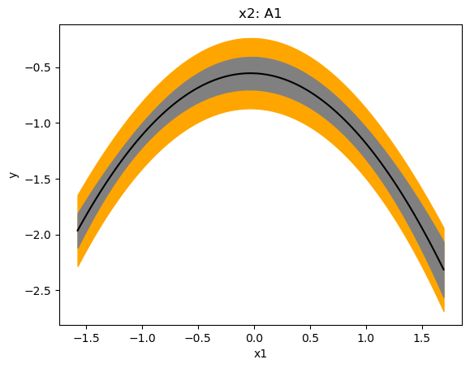

```python
fig, ax = plt.subplots()

# prediction interval
ax.fill_between( pred_viz_summary_5_combine_A1.x1,
                 pred_viz_summary_5_combine_A1.obs_ci_lower, pred_viz_summary_5_combine_A1.obs_ci_upper,
                 facecolor='orange', edgecolor='orange')

# confidence interval
ax.fill_between( pred_viz_summary_5_combine_A1.x1,
                 pred_viz_summary_5_combine_A1.mean_ci_lower, pred_viz_summary_5_combine_A1.mean_ci_upper,
                 facecolor='grey', edgecolor='grey' )

# predictive TREND - average output
ax.plot( pred_viz_summary_5_combine_A1.x1, pred_viz_summary_5_combine_A1['mean'], color='k')

# set the labels
ax.set_xlabel('x1')
ax.set_ylabel('y')
ax.set_title('x2: A1')

# show the plot
plt.show()
```

We can use matplotlib subplots to represent the OTHER categories of the OTHER input!!!

```python
the_x2_values = input_grid.x2.unique().tolist()
```

```python
the_x2_values
```

```
['A3', 'A1', 'A2']
```

Create the components of the figure within a for-loop which allows us to iterate over the values within `the_x2_values`.

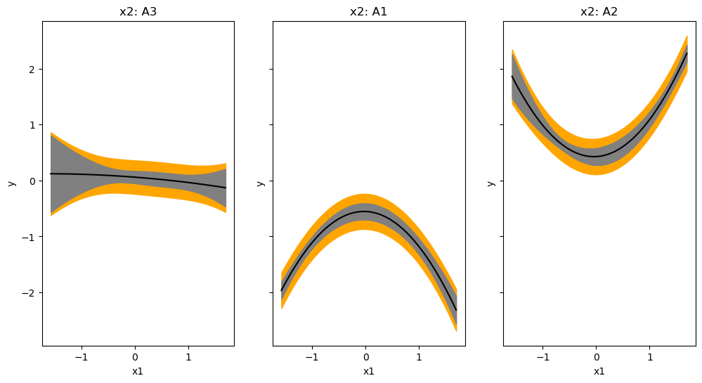

```python
fig, axs = plt.subplots(1, len(the_x2_values), figsize=(12,6), sharex=True, sharey=True)

ax = axs.ravel() # do NOT do this if axs is MULTIPLE rows!!!

for i, a_x2 in enumerate( the_x2_values ):
    # filter the data to a single category
    df_for_subplot = pred_viz_summary_5_combine.loc[ pred_viz_summary_5_combine.x2 == a_x2, : ].copy()

    # prediction interval
    ax[i].fill_between( df_for_subplot.x1,
                        df_for_subplot.obs_ci_lower, df_for_subplot.obs_ci_upper,
                        facecolor='orange', edgecolor='orange' )

    # confidence interval
    ax[i].fill_between( df_for_subplot.x1,
                        df_for_subplot.mean_ci_lower, df_for_subplot.mean_ci_upper,
                        facecolor='grey', edgecolor='grey')

    # trend
    ax[i].plot(df_for_subplot.x1, df_for_subplot['mean'], color='black')

    # set labels
    ax[i].set_xlabel('x1')
    ax[i].set_ylabel('y')
    ax[i].set_title('x2: %s' % a_x2)

# show the plot
plt.show()
```

```python
axs.shape
```

```
(3,)
```

```python
axs.ndim
```

```
1
```

## Dummies vs Onehots

The dummy variables derived from the categorical input are one way to DERIVE features from categorical inputs.

One hot encodings or "onehots" are an alternative approach. They share certain similarities but the interpretations are different.

```python
XA1_df_1.head()
```

|  | Intercept | x2[T.A2] | x2[T.A3] | intercept_product | dummy2_product | dummy3_product | model_pred |
| --- | --- | --- | --- | --- | --- | --- | --- |
| 0 | 1.0 | 0.0 | 1.0 | -1.339974 | 0.000000 | 1.372002 | 0.032028 |
| 1 | 1.0 | 0.0 | 0.0 | -1.339974 | 0.000000 | 0.000000 | -1.339974 |
| 2 | 1.0 | 1.0 | 0.0 | -1.339974 | 2.469504 | 0.000000 | 1.129530 |
| 3 | 1.0 | 1.0 | 0.0 | -1.339974 | 2.469504 | 0.000000 | 1.129530 |
| 4 | 1.0 | 0.0 | 1.0 | -1.339974 | 0.000000 | 1.372002 | 0.032028 |

Let's first create the ONEHOTS and examine them inside their design matrix and then consider their coefficients from their model.

By default the formula interface works with DUMMY variables. We can force ONE HOTS by "removing the intercept". You can "remove" or not-select a variable within the formula interface via the `-` operator.

```python
yA1_df_1onehot, XA1_df_1onehot = dmatrices('y ~ x2 - 1', data=dfA1, return_type='dataframe')
```

```python
XA1_df_1onehot.head()
```

|  | x2[A1] | x2[A2] | x2[A3] |
| --- | --- | --- | --- |
| 0 | 0.0 | 0.0 | 1.0 |
| 1 | 1.0 | 0.0 | 0.0 |
| 2 | 0.0 | 1.0 | 0.0 |
| 3 | 0.0 | 1.0 | 0.0 |
| 4 | 0.0 | 0.0 | 1.0 |

The one-hot encodings **REMOVE** the intercept feature and replace it with the reference category!

```python
XA1_df_1onehot.nunique()
```

```
x2[A1]    2
x2[A2]    2
x2[A3]    2
dtype: int64
```

```python
XA1_df_1onehot['x2[A1]'].value_counts()
```

```
x2[A1]
0.0    23
1.0    10
Name: count, dtype: int64
```

The impact on the coefficient estimates is that the ONE HOT encodings' coefficients correspond to the OUTPUT AVERAGE per category!

```python
fit_A_1.params
```

```
Intercept   -1.339974
x2[T.A2]     2.469504
x2[T.A3]     1.372002
dtype: float64
```

```python
fit_A_1onehot = smf.ols(formula='y ~ x2 - 1', data=dfA1).fit()
```

```python
fit_A_1onehot.params
```

```
x2[A1]   -1.339974
x2[A2]    1.129530
x2[A3]    0.032028
dtype: float64
```

```python
dfA1.groupby(['x2']).y.mean()
```

```
x2
A1   -1.339974
A2    1.129530
A3    0.032028
Name: y, dtype: float64
```

```python
fit_A_1onehot.pvalues < 0.05
```

```
x2[A1]     True
x2[A2]     True
x2[A3]    False
dtype: bool
```

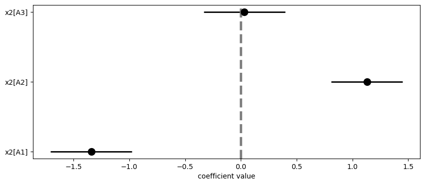

```python
my_coefplot( fit_A_1onehot )
```

You must be VERY careful with coefficient interpretation **especially** statistically significance when using ONE HOT ENCODINGS!!!!

The one hot encoding p-values just tell you if you are confident in the SIGN of the average output for each category!!!!

To use the p-value, "as it is", we are really supposed to consider **RELATIVE** changes!!!!!

```python
my_coefplot( fit_A_1 )
```

[output not shown]

### Pandas can create dummies and onehots for us

```python
dfA1.head()
```

|  | x1 | x2 | y |
| --- | --- | --- | --- |
| 0 | 1.340015 | A3 | -0.107934 |
| 1 | -1.575463 | A1 | -1.833471 |
| 2 | 1.595778 | A2 | 1.925451 |
| 3 | -0.758101 | A2 | 0.826788 |
| 4 | 1.299439 | A3 | -0.083876 |

```python
input_df = dfA1.loc[:, ['x1', 'x2']].copy()
```

```python
output_df = dfA1.loc[:, ['y']].copy()
```

```python
input_df.head()
```

|  | x1 | x2 |
| --- | --- | --- |
| 0 | 1.340015 | A3 |
| 1 | -1.575463 | A1 |
| 2 | 1.595778 | A2 |
| 3 | -0.758101 | A2 |
| 4 | 1.299439 | A3 |

```python
output_df.head()
```

|  | y |
| --- | --- |
| 0 | -0.107934 |
| 1 | -1.833471 |
| 2 | 1.925451 |
| 3 | 0.826788 |
| 4 | -0.083876 |

The `pd.get_dummies()` function will "extract" or DERIVE the dummies from the categorical variables!

```python
pd.get_dummies( input_df ).head()
```

|  | x1 | x2_A1 | x2_A2 | x2_A3 |
| --- | --- | --- | --- | --- |
| 0 | 1.340015 | False | False | True |
| 1 | -1.575463 | True | False | False |
| 2 | 1.595778 | False | True | False |
| 3 | -0.758101 | False | True | False |
| 4 | 1.299439 | False | False | True |

By default, `pd.get_dummies()`, does NOT return the dummy variables! It returns ONE HOTS!!!!!

```python
pd.get_dummies( input_df, drop_first=True ).head()
```

|  | x1 | x2_A2 | x2_A3 |
| --- | --- | --- | --- |
| 0 | 1.340015 | False | True |
| 1 | -1.575463 | False | False |
| 2 | 1.595778 | True | False |
| 3 | -0.758101 | True | False |
| 4 | 1.299439 | False | True |

But, I do not use these approaches that often. Because it actually makes it more challenging to create **INTERACTIONS** between categorical and numeric inputs via the formula interface!!!!